# Lesson 11-13: Data visualization

Mark Sibbald, Jurre Hageman

2025-10-17

[figure not shown]

Go back to the main page  
Go back to the R overview page

This file can be downloaded here.

## Lesson 11-13: Data visualization

Once the data is read/loaded and cleaned up nicely, it is time start analyzing and presenting the data. In these two lessons, we will look at the visualization part. We will use different plots to show the analysis and what it takes to make the data sets usable for each different plot.

First, let’s load a data set that we can work with which has been cleaned up already. Of course we start with the make up of the tibbles we create during this part of the lessons, like we did before in previous lessons using the `tidyverse` and `kableExtra` libraries.

```r
library(tidyverse)
library(kableExtra)
library(knitr)
library(pillar)
formatted_table <- function(df) {
  col_types <- sapply(df, pillar::type_sum)
  new_col_names <- paste0(names(df), "<br>", "<span style='font-weight: normal;'>", col_types, "</span>")
  kbl(df, col.names = new_col_names, escape = F, format = "html") %>%
    kable_styling(bootstrap_options = c("striped", "hoover", "responsive"))
}
```

Download the file dinoDatasetCSV.csv and check in a text editor what is the delimiter in the file. Read the file into R.

```r
# Read the data on dinosaurs.
dino_data <- read_csv2("./files_13_data_visualization_exercises/add_exercises/dinoDatasetCSV.csv")
# Replace any missing data with NA values.
# Hint: check which columns are of character type, but contains numbers.
tibble1 <- tibble(dino_data) %>%
  replace(.== "?", NA) %>%
  mutate(length_m = as.numeric(length_m)) %>%
  mutate(weight_kg = as.numeric(weight_kg)) %>%
  mutate(height_m = as.numeric(height_m))
formatted_table(head(tibble1))
```

| scientific_name chr | common_name chr | meaning chr | diet chr | length_m dbl | weight_kg dbl | height_m dbl | locomotion chr | period chr | lived_in chr | behavior_notes chr | first_discovered chr | fossil_location chr | notable_features chr | intelligence_level chr | source_link chr | row_index dbl |
| --- | --- | --- | --- | --- | --- | --- | --- | --- | --- | --- | --- | --- | --- | --- | --- | --- |
| Abelisaurus | Abelisaurus | Abel’s lizard | Carnivore | 7.0 | 1500 | 2.4 | Bipedal | Late Cretaceous | Argentina | Large theropod | 1985 | Argentina | Short arms | Medium | https://en.wikipedia.org/wiki/Abelisaurus | 0 |
| Abrictosaurus | Abrictosaurus | Wakeful lizard | Herbivore | 1.5 | 15 | 0.5 | Bipedal | Early Jurassic | South Africa | Small herbivore | 1974 | South Africa | Unique teeth | Medium | https://en.wikipedia.org/wiki/Abrictosaurus | 1 |
| Abrosaurus | Abrosaurus | Delicate lizard | Herbivore | 9.0 | 2000 | 4.5 | Quadrupedal | Middle Jurassic | China | Delicate skull | 1959 | China | Delicate skull | Medium | https://en.wikipedia.org/wiki/Abrosaurus | 2 |
| Abydosaurus | Abydosaurus | Abydos lizard | Herbivore | 18.0 | 30000 | 6.0 | Quadrupedal | Early Cretaceous | USA | Basal sauropod | 2010 | USA | Complete skull | Medium | https://en.wikipedia.org/wiki/Abydosaurus | 3 |
| Acantholipan | Acantholipan | Spiny shield | Herbivore | 5.0 | 2500 | 1.5 | Quadrupedal | Late Cretaceous | Mexico | Armored nodosaur | 2011 | Mexico | Clubless armored tail | Medium | https://en.wikipedia.org/wiki/Acantholipan | 4 |
| Acanthopholis | Acanthopholis | Spiny scales | Herbivore | 4.0 | 1000 | 1.2 | Quadrupedal | Early Cretaceous | UK | Spiny armor | 1865 | UK | Dermal armor | Medium | https://en.wikipedia.org/wiki/Acanthopholis | 5 |

## Summarize each

Let’s create a summary of the dinosaurs that lived in the Cretaceous period. We are only interested in the scientific name, length, weight and height of the animals.

```r
# Select the dinosaurs from the Middle Cretaceous period and sort them on scientific name and drop the rows that have NA values.
cretaceous <- tibble1 %>%
  filter(period == "Middle Cretaceous") %>%
  drop_na()

# Select only the columns containing the period, scientific name, length, weight and height.
sel_data <- cretaceous %>%
  arrange(scientific_name) %>%
  select(period, scientific_name, length_m, weight_kg, height_m)
# Change the colnames.
colnames(sel_data) <- c("Period", "Scientific name", "Length (m)",
                       "Weight (kg)", "Height (m)")
formatted_table(head(sel_data))
```

| Period chr | Scientific name chr | Length (m) dbl | Weight (kg) dbl | Height (m) dbl |
| --- | --- | --- | --- | --- |
| Middle Cretaceous | Dongyangosaurus | 15 | 12000 | 4.0 |
| Middle Cretaceous | Elaltitan | 21 | 15000 | 5.0 |
| Middle Cretaceous | Epachthosaurus | 17 | 14000 | 4.5 |
| Middle Cretaceous | Ichthyovenator | 9 | 3500 | 3.5 |
| Middle Cretaceous | Ornithomimoides | 4 | 100 | 1.5 |
| Middle Cretaceous | Stegosaurides | 7 | 3000 | 3.0 |

We will use this data to make different plots.

## Bar chart

Create a bar chart with ggplot of the weight of the dinosaurs of the Cretaceous period. Create a title (main and axis titles) and give the bars a `steelblue` color. Make sure that the labels on the x-axis are placed at a 45 degree angle.

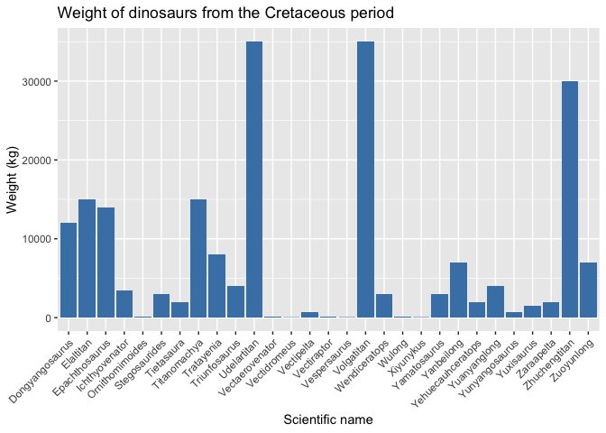

```r
# Create a bar chart with ggplot of the weight.
bar_dino <- ggplot(data = sel_data, aes(x = `Scientific name`, y = `Weight (kg)`)) +
  geom_bar(stat="identity", fill="steelblue") +
  labs(title="Weight of dinosaurs from the Cretaceous period") +
  theme(axis.text.x = element_text(angle = 45, hjust=1))
bar_dino
```

From the graph is clear that the **Udelartitan**, **Volgatitan** and **Zhuchengtitan** were the heaviest dinosaurs in the Cretaceous period (it is also clear from the name ‘titan’).

## Grouped Bar chart

Let’s compare the length to the height of the dinosaurs in one bar chart. First, you will have to make the data tidy with `pivot_longer()`. Then you can create the grouped bar chart.

```r
# Make the data tidy. Check if the data is indeed tidy (length and height should be indicated in a column called dimension).
tidy_data <- sel_data %>%
  pivot_longer(c(`Length (m)`, `Height (m)`), names_to = "Dimension",
               values_to = "Size (m)")
formatted_table(head(tidy_data))
```

| Period chr | Scientific name chr | Weight (kg) dbl | Dimension chr | Size (m) dbl |
| --- | --- | --- | --- | --- |
| Middle Cretaceous | Dongyangosaurus | 12000 | Length (m) | 15.0 |
| Middle Cretaceous | Dongyangosaurus | 12000 | Height (m) | 4.0 |
| Middle Cretaceous | Elaltitan | 15000 | Length (m) | 21.0 |
| Middle Cretaceous | Elaltitan | 15000 | Height (m) | 5.0 |
| Middle Cretaceous | Epachthosaurus | 14000 | Length (m) | 17.0 |
| Middle Cretaceous | Epachthosaurus | 14000 | Height (m) | 4.5 |

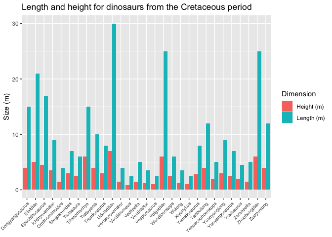

```r
# Plot the grouped bar chart.
dino_size1 <- ggplot(tidy_data, aes(`Scientific name`, `Size (m)`,
                                    fill = Dimension)) +
  geom_bar(stat = "identity", position = "dodge") +
  labs(title="Length and height for dinosaurs from the Cretaceous period",
       y = "Size (m)") +
  theme(axis.text.x = element_text(angle = 45, hjust=1, size = 7),
        axis.title.x = element_blank()) # leave out title of the x-axis
dino_size1
```

## Percent bar chart

You can create a percent bar chart to see what percentage is body length compared to body height.

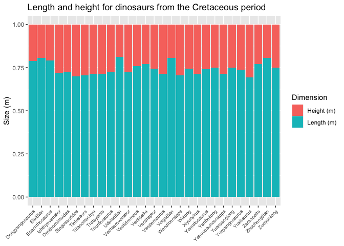

```r
# Create a percentage bar chart.
perc_dino_size1 <- ggplot(tidy_data, aes(`Scientific name`, `Size (m)`,
                                        fill = `Dimension`)) +
  geom_bar(stat = "identity", position="fill") +
  labs(title="Length and height for dinosaurs from the Cretaceous period") +
  theme(axis.text.x = element_text(angle = 45, hjust=1, size = 7),
        axis.title.x = element_blank())
perc_dino_size1
```

## Swithing orders in a group

If you would like to present the data in a different order, you need to change the column with the groups to the data type `factor`. You can put the length before the height in this way.

```r
# First, change the column of 'Dimension' to a factor type of data.
tidy_data <- tidy_data %>%
  mutate(Dimension = factor(Dimension,
                            levels = c("Length (m)", "Height (m)")))
levels(tidy_data$Dimension)
```

```
## [1] "Length (m)" "Height (m)"
```

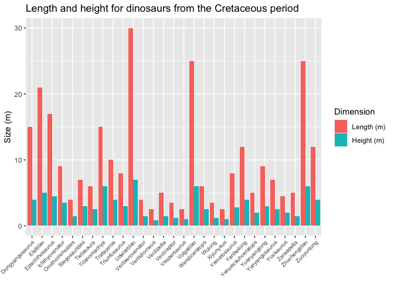

```r
# Second, plot the grouped bar chart.
dino_size2 <- ggplot(tidy_data, aes(`Scientific name`, `Size (m)`,
                                    fill = Dimension)) +
  geom_bar(stat = "identity", position = "dodge") +
  labs(title="Length and height for dinosaurs from the Cretaceous period",
       y = "Size (m)") +
  theme(axis.text.x = element_text(angle = 45, hjust=1, size = 7),
        axis.title.x = element_blank())
dino_size2
```

And use the same data to create a percentage bar chart.

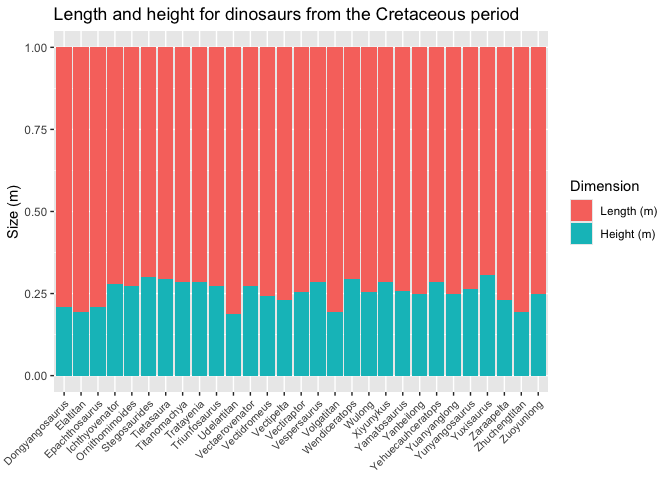

```r
# Create the percentage bar chart.
perc_dino_size2 <- ggplot(tidy_data, aes(`Scientific name`, `Size (m)`,
                                        fill = `Dimension`)) +
  geom_bar(stat = "identity", position="fill") +
  labs(title="Length and height for dinosaurs from the Cretaceous period") +
  theme(axis.text.x = element_text(angle = 45, hjust=1, size = 8),
        axis.title.x = element_blank())
perc_dino_size2
```

## Pie Chart

For a pie chart we will use a selection of the dinosaurs from the Cretaceous period, otherwise the pie would be divided in too many pieces, representing all the dinosaurs from this period.

```r
# Select the seven longest dinosaurs. Check your bar chart with the length and height of each Cretaceous dinosaur. Save these seven to a vector.
long_dino <- c("Dongyangosaurus", "Elaltitan", "Titanomachya", "Epachthosaurus", "Udelartitan",
               "Volgatitan", "Zhuchengtitan")
# Filter the data set using this vector.
df_long_dino1 <- sel_data %>%
  filter(`Scientific name`%in%long_dino)
formatted_table(df_long_dino1)
```

| Period chr | Scientific name chr | Length (m) dbl | Weight (kg) dbl | Height (m) dbl |
| --- | --- | --- | --- | --- |
| Middle Cretaceous | Dongyangosaurus | 15 | 12000 | 4.0 |
| Middle Cretaceous | Elaltitan | 21 | 15000 | 5.0 |
| Middle Cretaceous | Epachthosaurus | 17 | 14000 | 4.5 |
| Middle Cretaceous | Titanomachya | 15 | 15000 | 6.0 |
| Middle Cretaceous | Udelartitan | 30 | 35000 | 7.0 |
| Middle Cretaceous | Volgatitan | 25 | 35000 | 6.0 |
| Middle Cretaceous | Zhuchengtitan | 25 | 30000 | 6.0 |

```r
# OR select by using `slice_max()` and change the `Scientific name` to factor type of data (creates order in the pie chart):
df_long_dino2 <- sel_data %>%
  slice_max(order_by = `Length (m)`, n = 7) %>%
  mutate(`Scientific name` = factor(`Scientific name`,
                                levels = `Scientific name`))
formatted_table(df_long_dino2)
```

| Period chr | Scientific name fct | Length (m) dbl | Weight (kg) dbl | Height (m) dbl |
| --- | --- | --- | --- | --- |
| Middle Cretaceous | Udelartitan | 30 | 35000 | 7.0 |
| Middle Cretaceous | Volgatitan | 25 | 35000 | 6.0 |
| Middle Cretaceous | Zhuchengtitan | 25 | 30000 | 6.0 |
| Middle Cretaceous | Elaltitan | 21 | 15000 | 5.0 |
| Middle Cretaceous | Epachthosaurus | 17 | 14000 | 4.5 |
| Middle Cretaceous | Dongyangosaurus | 15 | 12000 | 4.0 |
| Middle Cretaceous | Titanomachya | 15 | 15000 | 6.0 |

Now create the pie chart.

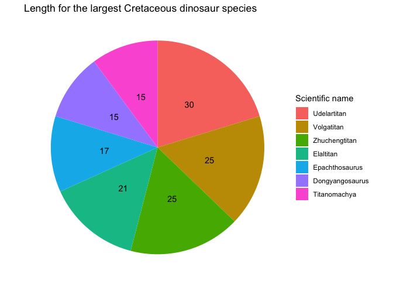

```r
# Create the pie chart based on the weight of these dinosaurs.
dino_pie1 <- ggplot(df_long_dino2, aes(x = "", y = `Length (m)`,
                                    fill = `Scientific name`))+
  geom_bar(stat="identity", width = 1) +
  coord_polar("y", start=0, direction = -1) +
  labs(title="Length for the largest Cretaceous dinosaur species") +
  geom_text(aes(label = `Length (m)`), position = position_stack(vjust = 0.5)) + # add values to the pieces of the pie.
  theme_void() # remove background, grid, numeric labels
dino_pie1
```

It seems that the ‘titans’ are the largest and heaviest dinosaurs (except the Elaltitan).  
If you really want to make it a fancy pie chart, you can try using the `ggrepel` library.

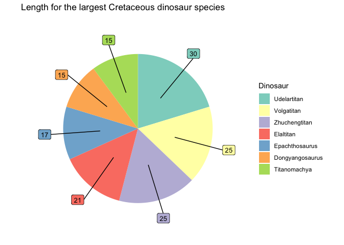

```r
# First, the position of the labels outside the pie chart have to be determined
library(ggrepel)
fancy_pie1 <- df_long_dino2 %>%
  # position the labels outside the pie chart correctly
  mutate(csum = rev(cumsum(rev(`Length (m)`))),
         pos = `Length (m)`/2 + lead(csum, 1),
         pos = if_else(is.na(pos), `Length (m)`/2, pos))

# Now plot the pie chart and insert the labels with `geom_label_repel()`.
dino_pie2 <- ggplot(fancy_pie1,
                    aes(x = "", y = `Length (m)`,
                        fill = fct_inorder(`Scientific name`))) +
  geom_bar(stat="identity", width = 1) +
  coord_polar("y", start=0, direction = -1) +
  scale_fill_brewer(palette = "Set3") + # color set for the pie chart
  # Create labels outside the pie chart
  geom_label_repel(data = fancy_pie1,
                   aes(y = pos, label = `Length (m)`),
                   size = 3.5, nudge_x = 0.75, show.legend = FALSE) +

  labs(title="Length for the largest Cretaceous dinosaur species") +
  guides(fill = guide_legend(title = "Dinosaur")) +
  theme_void() # remove background, grid, numeric labels
dino_pie2
```

Or with percentages:

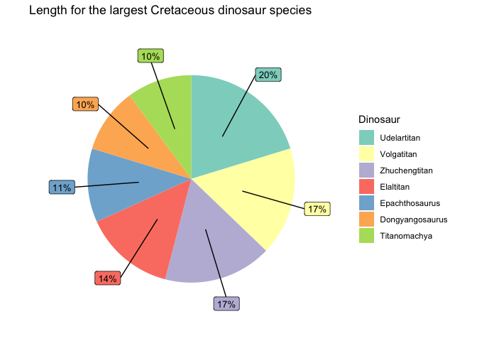

```r
# First add a column with the calculated percentages (of the total length).
fancy_pie2 <- fancy_pie1 %>%
  mutate(percentage = round(`Length (m)` / sum(`Length (m)`) * 100), 0)
# Then plot the same pie chart, but with the percentages instead of the length.
dino_pie3 <- ggplot(fancy_pie2,
                    aes(x = "", y = `Length (m)`,
                        fill = fct_inorder(`Scientific name`))) +
  geom_bar(stat="identity", width = 1) +
  coord_polar("y", start = 0, direction = -1) +
  scale_fill_brewer(palette = "Set3") + # color set for the pie chart
  # Create labels outside the pie chart
  geom_label_repel(data = fancy_pie2,
                   aes(y = pos, label = paste0(percentage, "%")),
                   size = 3.5, nudge_x = 0.75, show.legend = FALSE) +

  labs(title="Length for the largest Cretaceous dinosaur species") +
  guides(fill = guide_legend(title = "Dinosaur")) +
  theme_void() # remove background, grid, numeric labels
dino_pie3
```

## Boxplot

We can use the same data for the boxplot. Let’s look at the height of the dinosaurs in different periods of time.

```r
# Exclude (use `filter()`on tibble1) the dinosaurs that are heavier than 10000 kg
# Drop any NA values.
# Select the columns period, scientific name, length, weight and height,
# Make the data in the column period factor type data: Triassic < Jurassic < Cretaceous,
# Save the data in tibble2.
tibble2 <- tibble1 %>%
  filter(weight_kg <= 10000) %>%
  drop_na() %>%
  select(period, scientific_name, length_m, weight_kg, height_m) %>%
  mutate(period = factor(period, levels = c("Early Triassic", "Middle Triassic", "Late Triassic",
                                            "Early Jurassic", "Middle Jurassic", "Late Jurassic",
                                            "Early Cretaceous", "Middle Cretaceous", "Late Cretaceous")))
colnames(tibble2) <- c("Period", "Scientific name", "Length (m)",
                       "Weight (kg)", "Height (m)")
formatted_table(head(tibble2))
```

| Period fct | Scientific name chr | Length (m) dbl | Weight (kg) dbl | Height (m) dbl |
| --- | --- | --- | --- | --- |
| Late Cretaceous | Abelisaurus | 7.0 | 1500 | 2.4 |
| Early Jurassic | Abrictosaurus | 1.5 | 15 | 0.5 |
| Middle Jurassic | Abrosaurus | 9.0 | 2000 | 4.5 |
| Late Cretaceous | Acantholipan | 5.0 | 2500 | 1.5 |
| Early Cretaceous | Acanthopholis | 4.0 | 1000 | 1.2 |
| Late Cretaceous | Achelousaurus | 6.0 | 2500 | 2.0 |

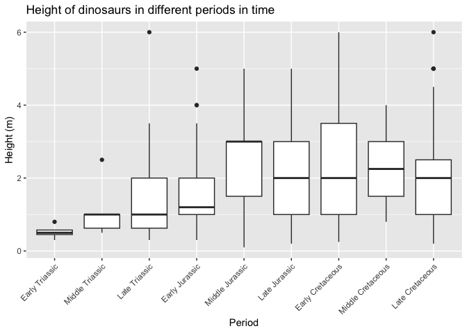

```r
# Create a boxplot for the height of the dinosaurs for each period in time.
height_period <- ggplot(tibble2, aes(x = `Period`, y = `Height (m)`)) +
  geom_boxplot() +
  labs(title="Height of dinosaurs in different periods in time",
       x = "Period", y = "Height (m)") +
  theme(axis.text.x = element_text(angle = 45, hjust=1))
height_period
```

It seems that the dinosaurs were growing large towards the Jurassic period and maintained that size during the Cretaceous period.

## Grouped boxplot

```r
# First make a tidy tibble from tibble2.
tidy_period <- tibble2 %>%
  pivot_longer(c(`Length (m)`, `Height (m)`), names_to = "Dimension",
               values_to = "Size (m)")
formatted_table(head(tidy_period))
```

| Period fct | Scientific name chr | Weight (kg) dbl | Dimension chr | Size (m) dbl |
| --- | --- | --- | --- | --- |
| Late Cretaceous | Abelisaurus | 1500 | Length (m) | 7.0 |
| Late Cretaceous | Abelisaurus | 1500 | Height (m) | 2.4 |
| Early Jurassic | Abrictosaurus | 15 | Length (m) | 1.5 |
| Early Jurassic | Abrictosaurus | 15 | Height (m) | 0.5 |
| Middle Jurassic | Abrosaurus | 2000 | Length (m) | 9.0 |
| Middle Jurassic | Abrosaurus | 2000 | Height (m) | 4.5 |

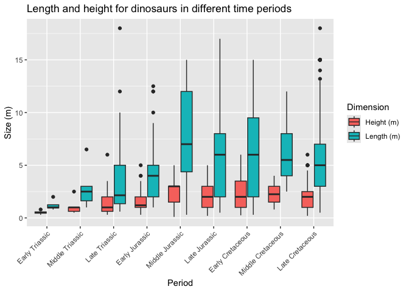

```r
# Now create the boxplot.
size_period1 <- ggplot(tidy_period, aes(x = `Period`, y = `Size (m)`, fill = Dimension)) +
  geom_boxplot() +
  labs(title="Length and height for dinosaurs in different time periods") +
  theme(axis.text.x = element_text(angle = 45, hjust=1))
size_period1
```

And if you like to change the order of the height and length, you will have to make the column for `Dimension` a factor type of data.

```r
# Make the column for 'Dimension' a factor type.
tidy_period <- tidy_period %>%
  mutate(Dimension = factor(Dimension, levels = c("Length (m)", "Height (m)")))
formatted_table(head(tidy_period))
```

| Period fct | Scientific name chr | Weight (kg) dbl | Dimension fct | Size (m) dbl |
| --- | --- | --- | --- | --- |
| Late Cretaceous | Abelisaurus | 1500 | Length (m) | 7.0 |
| Late Cretaceous | Abelisaurus | 1500 | Height (m) | 2.4 |
| Early Jurassic | Abrictosaurus | 15 | Length (m) | 1.5 |
| Early Jurassic | Abrictosaurus | 15 | Height (m) | 0.5 |
| Middle Jurassic | Abrosaurus | 2000 | Length (m) | 9.0 |
| Middle Jurassic | Abrosaurus | 2000 | Height (m) | 4.5 |

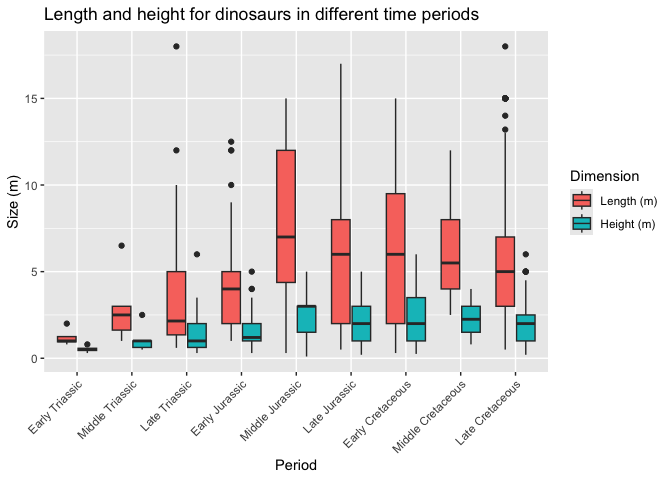

```r
# Create the boxplot.
size_period2 <- ggplot(tidy_period, aes(x = `Period`, y = `Size (m)`, fill = Dimension)) +
  geom_boxplot() +
  labs(title="Length and height for dinosaurs in different time periods") +
  theme(axis.text.x = element_text(angle = 45, hjust=1))
size_period2
```

## Violin Chart

Create with the same data a violin chart. Although these plots show more information about the data, it is more difficult to interpret the plots.

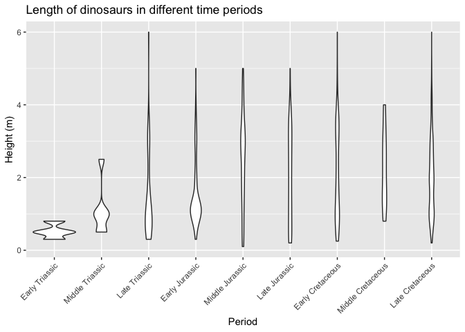

```r
# Create a violin chart from the Height (m) for the different time periods.
length_period <- ggplot(tibble2, aes(x = `Period`, y = `Height (m)`)) +
  geom_violin() +
  labs(title="Length of dinosaurs in different time periods") +
  theme(axis.text.x = element_text(angle = 45, hjust=1))
length_period
```

## Line plots

For the following plots we will use the Climate disease dataset.

```r
# Read the data from the file and save it in df1.
df1 <- read.csv2("./files_13_data_visualization_exercises/add_exercises/climate_disease_dataset.csv")
# Filter on the countries of the Netherlands, Sweden, Portugal and Hungary and the year 2023.
df2 <- df1 %>%
  filter(country == "Netherlands" | country == "Sweden" | country == "Portugal" |
           country == "Hungary") %>%
  slice_max(order_by = date, n = 480)
# Turn the first column to dates.
df2$date <- as.Date(df2$date, "%d/%m/%Y")
formatted_table(head(df2))
```

| date date | country chr | region chr | avg_temp_F dbl | precipitation_mm dbl | air_quality_index dbl | uv_index dbl | malaria_cases int | dengue_cases int | population_density int | healthcare_budget int | X dbl |
| --- | --- | --- | --- | --- | --- | --- | --- | --- | --- | --- | --- |
| 2023-12-01 | Portugal | West | 81.31159 | 216.72804 | 8.030935 | 12.000000 | 136 | 134 | 394 | 2520 | 178.3609 |
| 2023-12-01 | Sweden | West | 58.50859 | 318.78748 | 14.187193 | 9.076136 | 113 | 60 | 214 | 2681 | 137.3155 |
| 2023-12-01 | Hungary | Central | 62.04476 | 56.07903 | 0.000000 | 9.390880 | 83 | 52 | 107 | 4705 | 143.6806 |
| 2023-12-01 | Netherlands | Central | 83.97252 | 264.04019 | 71.588550 | 12.000000 | 92 | 66 | 421 | 1202 | 183.1505 |
| 2022-12-01 | Portugal | West | 75.53251 | 166.15460 | 59.467505 | 9.694721 | 65 | 119 | 394 | 2520 | 167.9585 |
| 2022-12-01 | Sweden | West | 60.34775 | 264.77139 | 0.000000 | 7.465901 | 67 | 102 | 214 | 2681 | 140.6259 |

Now we can create a line plot.

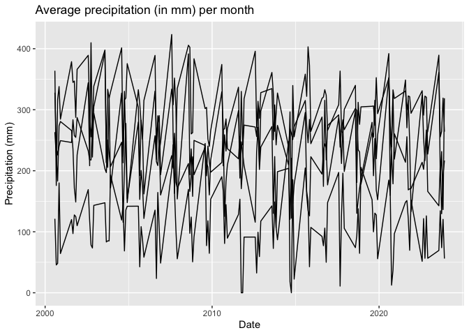

```r
# Create a line plot of the average precipitation against the date for the four selected continents with tidy data from df2.
line_plot1 <- ggplot(df2, aes(x = date, y = precipitation_mm, group = country)) +
  geom_line() +
  labs(title="Average precipitation (in mm) per month", x = "Date",
       y = "Precipitation (mm)")
line_plot1
```

This is not very clear since the data of each country is not visible. Let’s use some color to distinguish the data for the different countries.

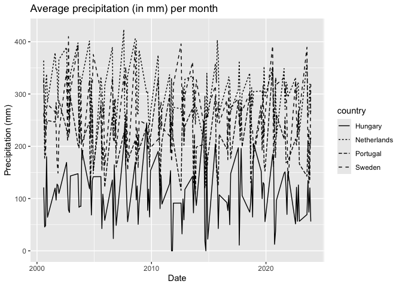

```r
# Use different types of lines to distinguish the data from the different countries.
line_plot2 <- ggplot(df2, aes(x = date, y = precipitation_mm, group = country)) +
  geom_line(aes(linetype = country)) +
  labs(title="Average precipitation (in mm) per month", x = "Date",
       y = "Precipitation (mm)")
line_plot2
```

This looks a bit better, but for this plot it is better to use colors to distinguish the data from the different countries.

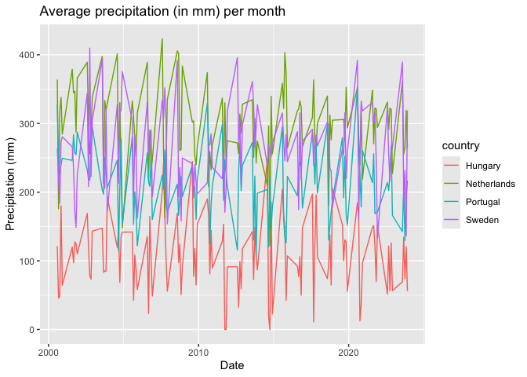

```r
# Create the same line plot as before, but use colors to distinguish the data for the different countries.
line_plot3 <- ggplot(df2, aes(x = date, y = precipitation_mm, group = country)) +
  geom_line(aes(color = country)) +
  labs(title="Average precipitation (in mm) per month", x = "Date",
       y = "Precipitation (mm)")
line_plot3
```

And add a trendline.

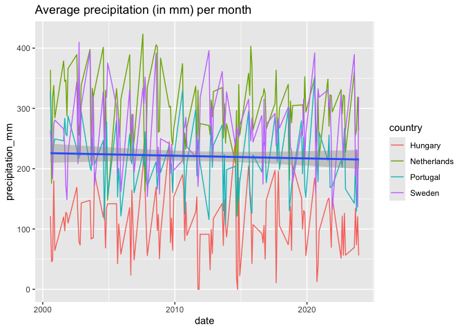

```r
# Add a trendline to the plot.
line_plot4 <- ggplot(df2, aes(x = date, y = precipitation_mm)) +
  geom_line(aes(color = country)) +
  labs(title="Average precipitation (in mm) per month") +
  geom_smooth(method="lm")
line_plot4
```

## Radar chart

For the radar chart we will use the Global Ecological Footprint data of 2023. To create radar charts you need to install the `remotes` package and load the `ggradar` library.

```r
# REMOVE THE HASH TAGS IN THE NEXT TWO LINES IF YOU HAVE NOT INSTALLED THE REMOTES PACKAGE YET.
#install.packages("remotes")
#remotes::install_github("ricardo-bion/ggradar")
library(ggradar)
```

Read the data from the Global Ecological Footprint data file.

```r
# Read the data and store it in a data frame.
footprint <- read_csv("./files_13_data_visualization_exercises/add_exercises/Global_Ecological_Footprint_2023.csv")
# Check which four European countries have the highest population.
# Select the columns for the country and the footprints (use the `ends_with()` function) for the four selected European countries.
big4 <- footprint %>%
  filter(Region == "EU-27") %>%
  slice_max(order_by = `Population (millions)`, n = 4) %>%
  arrange(Country) %>%
  select(Country, ends_with("Footprint"))
formatted_table(head(big4))
```

| Country chr | Cropland Footprint dbl | Grazing Footprint dbl | Forest Product Footprint dbl | Carbon Footprint dbl | Fish Footprint dbl |
| --- | --- | --- | --- | --- | --- |
| France | 1.0 | 0.3 | 0.5 | 2.2 | 0.2 |
| Germany | 0.9 | 0.2 | 0.5 | 2.7 | 0.1 |
| Italy | 0.8 | 0.3 | 0.5 | 2.0 | 0.2 |
| Spain | 1.2 | 0.2 | 0.2 | 1.8 | 0.5 |

Now create the radar chart.

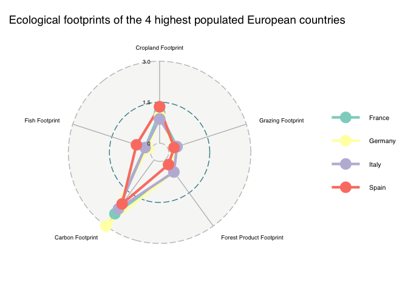

```r
# Create a radar chart from the data with the footprints for the 4 European countries.
big4_fp <- ggradar(big4,  legend.text.size = 8, values.radar = c("0", "1.5", "3.0"), axis.label.size = 2.5, grid.label.size = 3, legend.position = "right") +
  labs(title = "Ecological footprints of the 4 highest populated European countries") +
  theme(plot.title = element_text(size = 14, ))
big4_fp
```

## Bubble chart

Bubble charts are useful when you have an extra dimension that you would like to show in the plot.

```r
# Use the original data frame
# Check which four European countries have the highest population.
# Select the columns for the country and the footprints (use the `ends_with()` function) for the four selected European countries.
big4_fp <- footprint %>%
  filter(Region == "EU-27") %>%
  slice_max(order_by = `Population (millions)`, n = 4)
formatted_table(head(big4_fp))
```

| Country chr | Region chr | SDGi dbl | Life Exectancy dbl | HDI dbl | Per Capita GDP chr | Income Group chr | Population (millions) dbl | Cropland Footprint dbl | Grazing Footprint dbl | Forest Product Footprint dbl | Carbon Footprint dbl | Fish Footprint dbl | Built up land…14 dbl | Total Ecological Footprint (Consumption) dbl | Cropland dbl | Grazing land dbl | Forest land dbl | Fishing ground dbl | Built up land…20 dbl | Total biocapacity dbl | Ecological (Deficit) or Reserve dbl | Number of Earths required dbl | Number of Countries required dbl |
| --- | --- | --- | --- | --- | --- | --- | --- | --- | --- | --- | --- | --- | --- | --- | --- | --- | --- | --- | --- | --- | --- | --- | --- |
| Germany | EU-27 | 82.2 | 81 | 0.94 | $54,192 | HI | 83.9 | 0.9 | 0.2 | 0.5 | 2.7 | 0.1 | 0.2 | 4.5 | 0.6 | 0.1 | 0.6994546 | 0.0745313 | 0.1780850 | 1.6145357 | -2.884143 | 2.978833 | 2.786361 |
| France | EU-27 | 81.2 | 82 | 0.90 | $47,995 | HI | 65.6 | 1.0 | 0.3 | 0.5 | 2.2 | 0.2 | 0.2 | 4.3 | 1.0 | 0.2 | 0.9738287 | 0.1110340 | 0.1509272 | 2.4583718 | -1.854753 | 2.855967 | 1.754464 |
| Italy | EU-27 | 78.3 | 83 | 0.90 | $43,010 | HI | 60.3 | 0.8 | 0.3 | 0.5 | 2.0 | 0.2 | 0.1 | 4.0 | 0.4 | 0.1 | 0.3408854 | 0.0657797 | 0.0912344 | 0.9711389 | -2.980057 | 2.616313 | 4.068621 |
| Spain | EU-27 | 79.9 | 83 | 0.91 | $39,753 | HI | 46.7 | 1.2 | 0.2 | 0.2 | 1.8 | 0.5 | 0.1 | 3.9 | 1.1 | 0.1 | 0.4113462 | 0.0606709 | 0.0573795 | 1.7221554 | -2.193411 | 2.592720 | 2.273643 |

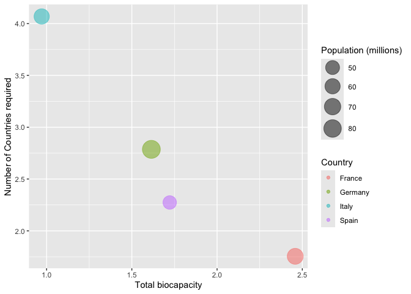

```r
# Create a bubble chart for the total the 'number of countries required' vs 'biocapacity' and as third dimension the 'population'.
bubble_big4 <- ggplot(big4_fp, aes(x = `Total biocapacity`, y = `Number of Countries required`)) +
  geom_point(aes(color = Country, size = `Population (millions)`), alpha = 0.5) +
  scale_size_area(max_size = 10)
bubble_big4
```

## Learning outcomes

This lesson you have learned to:  
- *visualize data using ggplot for:*  
- *creating a basic bar chart,*  
- *creating a grouped bar chart,*  
- *creating a percentage bar chart,*  
- *creating a box plot,*  
- *changing order in a grouped bar chart or box plot.*  
- *creating a violin chart,*  
- *creating a radar chart,*  
- *creating a bubble chart.*

— The end —

Go back to the main page  
Go back to the R overview page  
⬆️ Back to Top

> This web page is distributed under the terms of the Creative Commons Attribution License which permits unrestricted use, distribution, and reproduction in any medium, provided the original author and source are credited. Creative Commons License: CC BY-SA 4.0.